# Act Report

## Report: act_report

- Create a **250-word-minimum written report** called "act_report.pdf" or "act_report.html" that communicates the insights and displays the visualization(s) produced from your wrangled data. This is to be framed as an external document, like a blog post or magazine article, for example.

Dogs are beautiful creatures you can't help but love. Either as a cute puppy or a trained dog loyal to it's master. Having a social media account dedicated to showing us dogs and in all forms and breeds is the wonder we never knew we needed. This report focuses on the data wrangling process of a popular Twitter account (@weratedogs) that does just that, show us dogs in all formas and breed.

A brief summary into the Twitter account - WeRateDogs is a Twitter account started in 2015 that rates people’s dogs professionally (if professional means humorous comment about the dog). The account has over 9million followers currently.

This report shows the analysis, insight and visualisation of the weratedogs account/dataset. We had previously gone through the data wrangling process which involved gathering data over three sources, assessing these datframes visually and programtically for quaity and tidiness issues, and cleaning these issues.

To get insight into this analysis, several libraries were imported. See code below.

```python
import pandas as pd
import numpy as np
import matplotlib.pyplot as plt
%matplotlib inline
import seaborn as sns
```

```python
master_data = pd.read_csv('clean_master.csv')
```

### Research Question 1: What dog stage has the highest count and its impact on retweet and favourites count

Since we have a column for dog stage, let's find out the highest number of a stage and if that would mean high retweet count

```python
stages = master_data.dog_stage.value_counts()
print(stages)
```

```
pupper            203
doggo              63
puppo              22
doggo, pupper       9
floofer             7
doggo, puppo        1
doggo, floofer      1
Name: dog_stage, dtype: int64
```

This shows the count of dog stages in the dataframe with pupper having the highest number

```python
count = ['retweet_count', 'favorite_count']
dataset = master_data.groupby('dog_stage')[count].sum()
print(dataset)
```

```
                retweet_count  favorite_count
dog_stage
doggo                448919.0       1219452.0
doggo, floofer         3433.0         17169.0
doggo, pupper         36751.0        112798.0
doggo, puppo          19196.0         47844.0
floofer               34781.0         92442.0
pupper               479807.0       1461141.0
puppo                142427.0        474806.0
```

This shows the distribution of retweets and favourites for each dog stage with pupper having the highest retweets and likes

To reduce repititive code, we assign a label function that will be used in other visualisations

```python
def labels (a, b, c):
    """
    Args:
    a (str): x-axis title(weight = "bold")
    b (str): y-axis title(weight = 'bold')
    c (str): main title(weight = 'bold')


    Returns:
    None
    """

    plt.xlabel(a, weight = 'bold')
    plt.ylabel(b, weight = 'bold')
    plt.title(c, fontsize = 14, weight = 'bold')
    plt.show()
```

### Research Question 2: What isthe highest value count for a dog breed in the dataset?

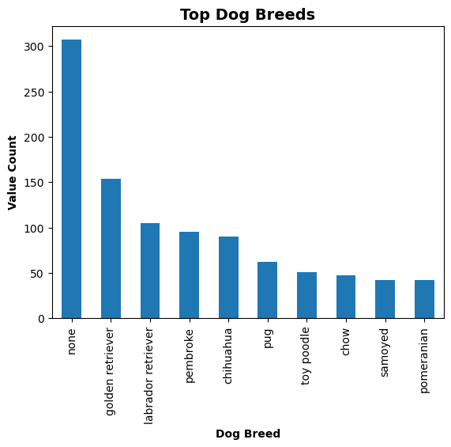

```python
master_data['dog_breed'].value_counts()[:10].plot(kind= 'bar')
labels('Dog Breed', 'Value Count', 'Top Dog Breeds')
```

### Research Question 3: Is there a relationship between Retweet and Favourite count

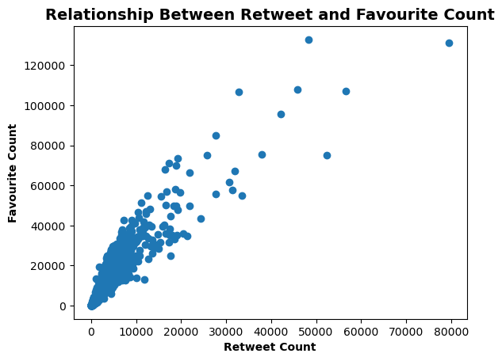

```python
plt.scatter(master_data.retweet_count, master_data.favorite_count)
labels('Retweet Count', 'Favourite Count', 'Relationship Between Retweet and Favourite Count')
```

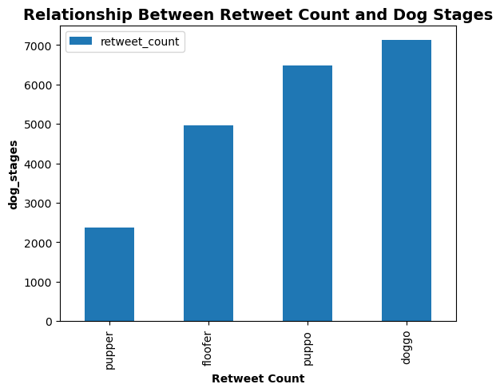

```python
master_data_stage = master_data[master_data["dog_stage"].isnull()==False]
by_stages = master_data_stage.query('dog_stage=="pupper" or dog_stage=="doggo" or dog_stage=="puppo" or dog_stage=="floofer"')
retweet_counts_by_stages = pd.DataFrame(by_stages.groupby('dog_stage').retweet_count.mean().sort_values())
retweet_counts_by_stages['stages'] = retweet_counts_by_stages.index
retweet_counts_by_stages.plot(x="stages",y='retweet_count',kind='bar')
labels('Retweet Count', 'dog_stages', 'Relationship Between Retweet Count and Dog Stages')
```

This graphical representation shows the distribution of retweet count for each dog stage with Doggo having the highest retweet counts

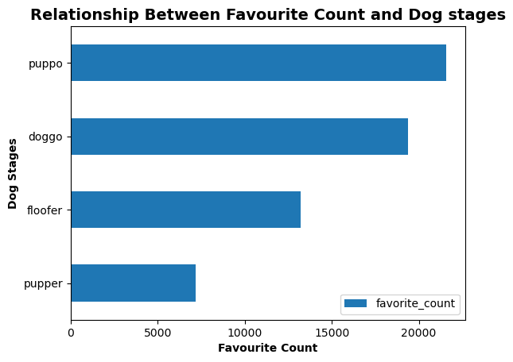

```python
master_data_stage = master_data[master_data["dog_stage"].isnull()==False]
by_stages = master_data_stage.query('dog_stage=="pupper" or dog_stage=="doggo" or dog_stage=="puppo" or dog_stage=="floofer"')
favorite_counts_by_stages = pd.DataFrame(by_stages.groupby('dog_stage').favorite_count.mean().sort_values())
favorite_counts_by_stages['stages'] = favorite_counts_by_stages.index
favorite_counts_by_stages.plot(x="stages",y='favorite_count',kind='barh')
labels('Favourite Count', 'Dog Stages', 'Relationship Between Favourite Count and Dog stages')
```

This graphical representation shows the relationship between favourites counts and dog stages, Puppo has the highest favourites count followed by doggo.

### Research Question 4: What is the relationship between dog breed and retweet and favourites count?

```python
count = ['favorite_count']
dataset = master_data.groupby(count)['dog_breed'].sum()
grouped = dataset.groupby(count, sort=False).sum()
grouped.sort_index(ascending=False)[:10]
```

[output not shown]

```python
count = ['retweet_count', 'favorite_count']
dataset = master_data.groupby(count)['dog_breed'].sum()
grouped = dataset.groupby(count, sort=False).sum()
grouped.sort_index(ascending=False)[:10]
```

```
retweet_count  favorite_count
79515.0        131075.0          labrador retriever
56625.0        107015.0                   chihuahua
52360.0        75163.0                   eskimo dog
48265.0        132810.0            lakeland terrier
45849.0        107956.0            english springer
42228.0        95450.0              standard poodle
37911.0        75639.0               cocker spaniel
33421.0        55016.0                         none
32883.0        106827.0              french bulldog
31989.0        67100.0                      whippet
Name: dog_breed, dtype: object
```

## Conclusion

[output not shown]